# jp2EDA

## 1. Contexto

En este conjunto de datos relacionados con los pingüinos implica examinar y visualizar los patrones y relaciones presentes en los datos. A continuacion, se busca respuesta a las siguientes preguntas:

1. ¿Cual es la vida promedio de un pinguino?
2. ¿Viven as las hembras o los machos?
3. ¿La altura es un rasgo distintivo del sexo?
4. ¿Cual es la proporción altura/ancho de los picos?
5. ¿Qué tipo de datos son las variables del conjunto de datos?
6. ¿Cuantas variables de cada tipo de dato tenemos en el conjunto de datos?
7. ¿Cuantas observaciones y variables tenemos en el conjunto de datos?
8. ¿Existen valores nulos explícitos en el conjunto de datos?
9. ¿De tener observaciones con valores nulos? ¿Cuántas tenemos por cada variable?
10. ¿Cuantos valores nulos tenemos en el total en el conjunto de datos?

Las columnas son:

- species: penguin species (Chinstrap, Adélie, or Gentoo)
- culmen_length_mm: culmen length (mm)
- culmen_depth_mm: culmen depth (mm)
- flipper_length_mm: flipper length (mm)
- body_mass_g: body mass (g)
- island: island name (Dream, Torgersen, or Biscoe) in the Palmer - - Archipelago (Antarctica)
- sex: penguin sex
1. species (especie): Esta variable representa la especie de pingüino a la que pertenece cada entrada en el conjunto de datos. Hay tres especies de pingüinos incluidas en este conjunto de datos: Chinstrap, Adélie y Gentoo. Cada entrada estará etiquetada con una de estas especies.
2. culmen_length_mm (longitud del culmen en mm): El culmen es el pico de un ave. Esta variable mide la longitud del culmen de cada pingüino en milímetros. La longitud del culmen es una característica importante para distinguir entre diferentes especies de pingüinos.
3. culmen_depth_mm (profundidad del culmen en mm): Esta variable mide la profundidad del culmen de cada pingüino en milímetros. Al igual que la longitud del culmen, la profundidad del culmen es una característica útil para identificar las especies de pingüinos.
4. flipper_length_mm (longitud de la aleta en mm): Mide la longitud de la aleta de cada pingüino en milímetros. La longitud de la aleta puede variar entre especies y es un indicador importante en la clasificación de los pingüinos.
5. body_mass_g (masa corporal en gramos): Esta variable indica la masa corporal de cada pingüino en gramos. La masa corporal es otra característica crítica para diferenciar entre especies y también puede proporcionar información sobre la salud y el estado de los pingüinos.
6. island (isla): Representa el nombre de la isla en la que se encuentra cada pingüino. Las tres islas mencionadas son Dream, Torgersen y Biscoe, que forman parte del Archipiélago Palmer en la Antártida. La ubicación geográfica puede tener un impacto en las características de los pingüinos.
7. sex (sexo): Indica el sexo de cada pingüino, ya sea macho o hembra.

**Observaciones:**

- El culmen es el pico
- flipper (aletas) =Las alas de los pingüinos se llaman aletas. Son planos, delgados y anchos con una forma larga y cónica y una punta roma y redondeada.

## 2. El dataset después de la limpieza

El dataset ha sido limpiado dando como resultado un total de 333 filas y 9 columnas

## 3. Lectura del dataset

```python
# Iimportando liberias
import pandas as pd
import matplotlib.pyplot as plt
import seaborn as sns
```

```python
# Lectura del dataset
ruta = "../results/dataset_penguins_clean.csv"
data = pd.read_csv(ruta)
```

```python
# Mostrando el dataset
print(data.shape)
data.head()
```

```
(333, 9)
```

|  | rowid | species | island | bill_length_mm | bill_depth_mm | flipper_length_mm | body_mass_g | sex | year |
| --- | --- | --- | --- | --- | --- | --- | --- | --- | --- |
| 0 | 1 | Adelie | Torgersen | 39.1 | 18.7 | 181.0 | 3750.0 | male | 2007 |
| 1 | 2 | Adelie | Torgersen | 39.5 | 17.4 | 186.0 | 3800.0 | female | 2007 |
| 2 | 3 | Adelie | Torgersen | 40.3 | 18.0 | 195.0 | 3250.0 | female | 2007 |
| 3 | 5 | Adelie | Torgersen | 36.7 | 19.3 | 193.0 | 3450.0 | female | 2007 |
| 4 | 6 | Adelie | Torgersen | 39.3 | 20.6 | 190.0 | 3650.0 | male | 2007 |

## 4. Análisis exploratorio (EDA)

La idea es usar herramientas estadísticas y de visualización para:

- Crear un mapa mental del set de datos (entenderlo)
- Empezar a encontrar respuestas a las preguntas planteadas inicialmente.

Se llevará a cabo estas fases:

1. Análisis de cada variable de manera individual
2. Análisis univariado: relación de cada variable predictora con la variable a predecir
3. Análisis bivariado: relación de pares de variables predictoras con la variable a predecir

## 4.1 Análisis de cada variable de manera individual

Esto nos permitira entender las caracteristicas generales de cada variable del dataset.

```python
# Primero que ndad, veremos las variables categoricas.
# Son del tipo: Dtype=object()
data.info()
```

```
<class 'pandas.core.frame.DataFrame'>
RangeIndex: 333 entries, 0 to 332
Data columns (total 9 columns):
 #   Column             Non-Null Count  Dtype
---  ------             --------------  -----
 0   rowid              333 non-null    int64
 1   species            333 non-null    object
 2   island             333 non-null    object
 3   bill_length_mm     333 non-null    float64
 4   bill_depth_mm      333 non-null    float64
 5   flipper_length_mm  333 non-null    float64
 6   body_mass_g        333 non-null    float64
 7   sex                333 non-null    object
 8   year               333 non-null    int64
dtypes: float64(4), int64(2), object(3)
memory usage: 23.5+ KB
```

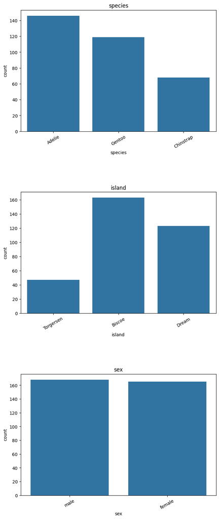

```python
# Veamos las variables categoricas en graficos de barras.
columnas_categoricas = ['species', 'island', 'sex']

# Graficas de barras de conteo
fig, ax = plt.subplots(nrows=len(columnas_categoricas),
                       ncols=1, figsize=(8, 20))
fig.subplots_adjust(hspace=0.5)

for i, col in enumerate(columnas_categoricas):
    sns.countplot(x=col, data=data, ax=ax[i])
    ax[i].set_title(col)
    ax[i].set_xticklabels(ax[i].get_xticklabels(), rotation=30)
```

```python
# Volvamos a ver las variables del dataset
print("Variables del dataset:")
data.info()

# Ahora, extraemos las variables estadisticas descriptivas basicas.
print("\nVariables estadisticas descriptivas basicas:")
data.describe()
```

```
Variables del dataset:
<class 'pandas.core.frame.DataFrame'>
RangeIndex: 333 entries, 0 to 332
Data columns (total 9 columns):
 #   Column             Non-Null Count  Dtype
---  ------             --------------  -----
 0   rowid              333 non-null    int64
 1   species            333 non-null    object
 2   island             333 non-null    object
 3   bill_length_mm     333 non-null    float64
 4   bill_depth_mm      333 non-null    float64
 5   flipper_length_mm  333 non-null    float64
 6   body_mass_g        333 non-null    float64
 7   sex                333 non-null    object
 8   year               333 non-null    int64
dtypes: float64(4), int64(2), object(3)
memory usage: 23.5+ KB

Variables estadisticas descriptivas basicas:
```

|  | rowid | bill_length_mm | bill_depth_mm | flipper_length_mm | body_mass_g | year |
| --- | --- | --- | --- | --- | --- | --- |
| count | 333.000000 | 333.000000 | 333.000000 | 333.000000 | 333.000000 | 333.000000 |
| mean | 174.324324 | 43.992793 | 17.164865 | 200.966967 | 4207.057057 | 2008.042042 |
| std | 98.386547 | 5.468668 | 1.969235 | 14.015765 | 805.215802 | 0.812944 |
| min | 1.000000 | 32.100000 | 13.100000 | 172.000000 | 2700.000000 | 2007.000000 |
| 25% | 90.000000 | 39.500000 | 15.600000 | 190.000000 | 3550.000000 | 2007.000000 |
| 50% | 173.000000 | 44.500000 | 17.300000 | 197.000000 | 4050.000000 | 2008.000000 |
| 75% | 259.000000 | 48.600000 | 18.700000 | 213.000000 | 4775.000000 | 2009.000000 |
| max | 344.000000 | 59.600000 | 21.500000 | 231.000000 | 6300.000000 | 2009.000000 |

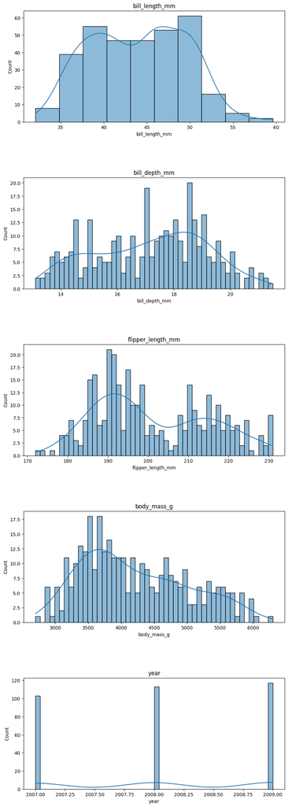

```python
# Es mejor graficasr estas variables estadisticas.

# Dibujaremos hisogramas
columnas_numericas = ['bill_length_mm', 'bill_depth_mm',
                      'flipper_length_mm', 'body_mass_g', 'year']

# Cuantos graficos se mostraran
fig, ax = plt.subplots(nrows=5, ncols=1, figsize=(10, 30))
fig.subplots_adjust(hspace=0.5)

for i, col in enumerate(columnas_numericas):
    if col == 'bill_length_mm':
        nbins = 10
    else:
        nbins = 50
    sns.histplot(x=col, data=data, ax=ax[i], bins=nbins, kde=True)
    ax[i].set_title(col)
```

## 4.1.2 Detallando las variables estadisticas

Ahora veremos a detalle lo que ocurre con todas y cada una de las variables estadisticas.

```python
data['bill_length_mm'].describe()
```

```
count    333.000000
mean      43.992793
std        5.468668
min       32.100000
25%       39.500000
50%       44.500000
75%       48.600000
max       59.600000
Name: bill_length_mm, dtype: float64
```

```python
data['bill_depth_mm'].describe()
```

```
count    333.000000
mean      17.164865
std        1.969235
min       13.100000
25%       15.600000
50%       17.300000
75%       18.700000
max       21.500000
Name: bill_depth_mm, dtype: float64
```

```python
data['flipper_length_mm'].describe()
```

```
count    333.000000
mean     200.966967
std       14.015765
min      172.000000
25%      190.000000
50%      197.000000
75%      213.000000
max      231.000000
Name: flipper_length_mm, dtype: float64
```

```python
data['body_mass_g'].describe()
```

```
count     333.000000
mean     4207.057057
std       805.215802
min      2700.000000
25%      3550.000000
50%      4050.000000
75%      4775.000000
max      6300.000000
Name: body_mass_g, dtype: float64
```

```python
data['year'].describe()
```

```
count     333.000000
mean     2008.042042
std         0.812944
min      2007.000000
25%      2007.000000
50%      2008.000000
75%      2009.000000
max      2009.000000
Name: year, dtype: float64
```

## Respondiendo con datos

```python
#data['']
```

Esta dos secciones quedarán para un posterior avance, debido a que, aun no se ven a detalle. Incluso se tienen ciertos problemas para continuar.

## 4.2 Análisis univariado

## 4.3 Análisis bivariado